# Questionnaire LabPhon - Rating & WordClouds

Jalal Al-Tamimi

Université de Paris

02 February 2022

Let’s look at the responses from the “Questionnaire LabPhon”. We look at your responses giving ratings of level of knowledge. We then look at identifying the words you used often in your free text.

# 1 Loading packages

```r
## Use the code below to check if you have all required packages installed. If some are not installed already, the code below will install these. If you have all packages installed, then you could load them with the second code.
requiredPackages = c('tidyverse', 'ordinal', 'tm', 'SnowballC', 'wordcloud', 'RColorBrewer', 'quanteda', 'quanteda.textplots')
for(p in requiredPackages){
  if(!require(p,character.only = TRUE)) install.packages(p)
  library(p,character.only = TRUE)
}
```

# 2 Mean ratings

```r
ratingMean <- read.csv("Questionnaire_LabPhon_rating_mean.csv")
ratingMean$Questions <- as.factor(ratingMean$Questions)
str(ratingMean)
```

```
'data.frame':   7 obs. of  2 variables:
 $ Questions: Factor w/ 7 levels "Q1","Q2","Q3",..: 1 2 3 4 5 6 7
 $ Response : num  2.93 3.36 2.64 1.93 2 ...
```

## 2.1 Raw

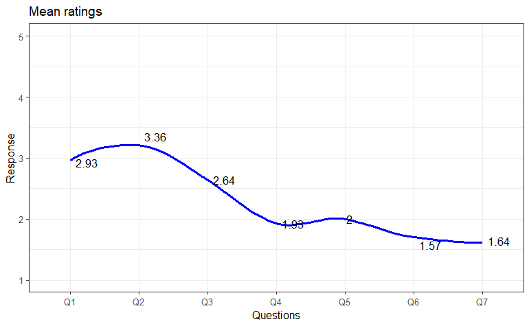

```r
ratingMean %>%
  ggplot(aes(x = Questions, y = Response)) +
geom_smooth(aes(x = as.numeric(Questions), y = Response), color = "blue", se = F) +
  coord_cartesian(ylim = c(1, 5)) +
  scale_x_discrete(limits = c("Q1", "Q2", "Q3", "Q4", "Q5", "Q6", "Q7")) +
  theme_bw() +
   stat_sum(aes(label = paste(round(Response, 2), sep = "")),
           size = 4, hjust = -0.25, geom = "text", show.legend = FALSE)  +
  labs(title = "Mean ratings")
```

```r
png(filename = "ratingMean1.png", width = 20, height = 15, units = "cm", res = 300)
ratingMean %>%
  ggplot(aes(x = Questions, y = Response)) +
geom_smooth(aes(x = as.numeric(Questions), y = Response), color = "blue", se = F) +
  coord_cartesian(ylim = c(1, 5)) +
  scale_x_discrete(limits = c("Q1", "Q2", "Q3", "Q4", "Q5", "Q6", "Q7")) +
  theme_bw() +
   stat_sum(aes(label = paste(round(Response, 2), sep = "")),
           size = 4, hjust = -0.25, geom = "text", show.legend = FALSE)  +
  labs(title = "Mean ratings")
dev.off()
```

## 2.2 Proportion

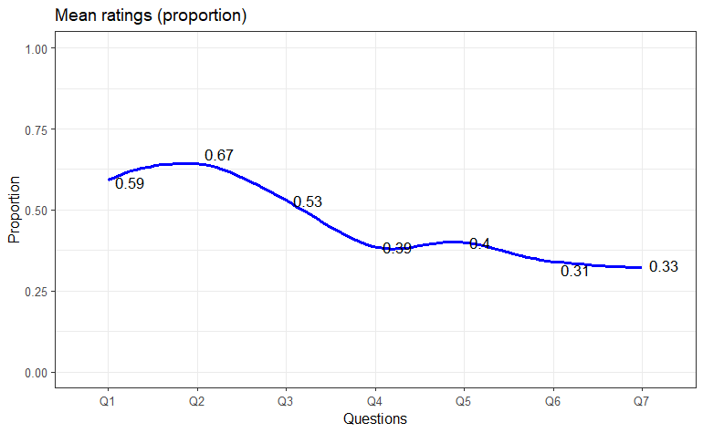

```r
ratingMean %>%
  mutate(Proportion = Response / 5) %>%
  ggplot(aes(x = Questions, y = Proportion)) +
geom_smooth(aes(x = as.numeric(Questions), y = Proportion), color = "blue", se = F) +
  coord_cartesian(ylim = c(0, 1)) +
  scale_x_discrete(limits = c("Q1", "Q2", "Q3", "Q4", "Q5", "Q6", "Q7")) +
  theme_bw() +
  stat_sum(aes(label = paste(round(Proportion, 2), sep = "")),
           size = 4, hjust = -0.25, geom = "text", show.legend = FALSE) +
  labs(title = "Mean ratings (proportion)")
```

```r
png(filename = "ratingMean2.png", width = 20, height = 15, units = "cm", res = 300)
ratingMean %>%
  mutate(Proportion = Response / 5) %>%
  ggplot(aes(x = Questions, y = Proportion)) +
geom_smooth(aes(x = as.numeric(Questions), y = Proportion), color = "blue", se = F) +
  coord_cartesian(ylim = c(0, 1)) +
  scale_x_discrete(limits = c("Q1", "Q2", "Q3", "Q4", "Q5", "Q6", "Q7")) +
  theme_bw() +
  stat_sum(aes(label = paste(round(Proportion, 2), sep = "")),
           size = 4, hjust = -0.25, geom = "text", show.legend = FALSE) +
  labs(title = "Mean ratings (proportion)")
dev.off()
```

# 3 Cumulative Link Models

These models work perfectly with rating data. Ratings are inherently ordered, 1, 2, … n, and expect to observe an increase (or decrease) in overall ratings from 1 to n. To demonstrate this, we will use an example using the package “ordinal”. Based on the responses given to each of the 7 questions, you provided responses from 1 to 5 based on category names.

## 3.1 Importing and pre-processing

We start by importing the data and process it.

```r
rating <- read.csv("Questionnaire_LabPhon_rating.csv")
str(rating)
```

```
'data.frame':   14 obs. of  8 variables:
 $ subject: chr  "S01" "S02" "S03" "S04" ...
 $ Q1     : int  3 4 4 2 3 2 4 2 2 1 ...
 $ Q2     : int  3 4 4 3 4 2 4 3 2 4 ...
 $ Q3     : int  3 3 3 2 3 2 4 2 2 3 ...
 $ Q4     : int  1 3 3 1 3 1 3 1 1 3 ...
 $ Q5     : int  3 3 3 2 2 1 4 1 1 3 ...
 $ Q6     : int  2 2 1 2 2 1 3 2 1 2 ...
 $ Q7     : int  1 1 3 1 2 1 3 4 1 1 ...
```

```r
## we need to convert "Response" to a factor

rating <- rating %>%
  pivot_longer(-subject,
               names_to = "Questions",
               values_to = "Responses")
rating
```

| subject | Questions | Responses |
| --- | --- | --- |
| S01 | Q1 | 3 |
| S01 | Q2 | 3 |
| S01 | Q3 | 3 |
| S01 | Q4 | 1 |
| S01 | Q5 | 3 |
| S01 | Q6 | 2 |
| S01 | Q7 | 1 |
| S02 | Q1 | 4 |
| S02 | Q2 | 4 |
| S02 | Q3 | 3 |

[output cut: 88 more lines]

```r
rating$subject <- as.factor(rating$subject)
rating$Questions <- as.factor(rating$Questions)
rating$Responses <- as.factor(rating$Responses)
str(rating)
```

```
tibble [98 x 3] (S3: tbl_df/tbl/data.frame)
 $ subject  : Factor w/ 14 levels "S01","S02","S03",..: 1 1 1 1 1 1 1 2 2 2 ...
 $ Questions: Factor w/ 7 levels "Q1","Q2","Q3",..: 1 2 3 4 5 6 7 1 2 3 ...
 $ Responses: Factor w/ 5 levels "1","2","3","4",..: 3 3 3 1 3 2 1 4 4 3 ...
```

## 3.2 Model specification

As you can see, the model specification follows that of any mixed-effects model. Because we have multiple responses from each participant, we used the model specifications to account for individual responses (a maximal model specification failed to converge). This is because we lack repetitions within each of the questions.

```r
mdl.clmm <- rating %>%
  clmm(Responses ~ Questions+ (1|subject), data =.)
summary(mdl.clmm)
```

```
Cumulative Link Mixed Model fitted with the Laplace approximation

formula: Responses ~ Questions + (1 | subject)
data:    .
```

| link | threshold | nobs | logLik | AIC | niter | max.grad | cond.H |
| --- | --- | --- | --- | --- | --- | --- | --- |
| logit | flexible | 98 | -98.74 | 219.48 | 619(2395) | 1.78e-05 | 8.7e+01 |

```
Random effects:
 Groups  Name        Variance Std.Dev.
 subject (Intercept) 3.758    1.939
Number of groups:  subject 14

Coefficients:
            Estimate Std. Error z value Pr(>|z|)
QuestionsQ2   1.3624     0.7928   1.718 0.085721 .
QuestionsQ3  -0.9758     0.7501  -1.301 0.193278
QuestionsQ4  -3.2477     0.8785  -3.697 0.000218 ***
QuestionsQ5  -2.9394     0.8609  -3.414 0.000639 ***
QuestionsQ6  -4.2711     0.9527  -4.483 7.35e-06 ***
QuestionsQ7  -4.6178     1.0152  -4.549 5.40e-06 ***
---
Signif. codes:  0 ‘***’ 0.001 ‘**’ 0.01 ‘*’ 0.05 ‘.’ 0.1 ‘ ’ 1

Threshold coefficients:
    Estimate Std. Error z value
1|2  -3.9157     0.9162  -4.274
2|3  -1.7410     0.8145  -2.138
3|4   1.6959     0.8350   2.031
4|5   5.9149     1.4327   4.129
```

## 3.3 Interpreting a cumulative model

As a way to interpret the model, we can look at the coefficients and make sense of the results. A CLM model is a Logistic model with a cumulative effect. The “Coefficients” are the estimates for each level of the fixed effect; the “Threshold coefficients” are those of the response. For the former, a negative coefficient indicates a negative association with the response; and a positive is positively associated with the response. The p values are indicating the significance of each level. For the “Threshold coefficients”, we can see the cumulative effects of ratings 1|2, 2|3, 3|4 and 4|5 which indicate an overall increase in the ratings from 1 to 5.

## 3.4 Plotting

We use a modified version of a plotting function that allows us to visualise the effects. For this, we use the base R plotting functions

```r
par(oma=c(0, 0, 0, 6), mgp=c(2, 1, 0))
xlim = c(min(mdl.clmm$beta), max(mdl.clmm$beta))
ylim = c(0,1)
plot(0,0,xlim=xlim, ylim=ylim, type="n", ylab=expression(Probability), xlab="", xaxt = "n",main="Predicted curves - LabPhon Questionnaire",cex=2,cex.lab=1.5,cex.main=1.5,cex.axis=1.5)
axis(side = 1, at = c(0,mdl.clmm$beta),labels = levels(rating$Questions), las=2,cex=2,cex.lab=1.5,cex.axis=1.5)
```

```r
xs = seq(xlim[1], xlim[2], length.out=100)

#+CI
lines(xs, plogis(mdl.clmm$Theta[1]+(summary(mdl.clmm)$coefficient[,2][[1]]/1.96) - xs), col='red')
lines(xs, plogis(mdl.clmm$Theta[2]+(summary(mdl.clmm)$coefficient[,2][[2]]/1.96) - xs)-plogis(mdl.clmm$Theta[1]+(summary(mdl.clmm)$coefficient[,2][[1]]/1.96) - xs), col='orange2')
```

```r
lines(xs, plogis(mdl.clmm$Theta[3]+(summary(mdl.clmm)$coefficient[,2][[3]]/1.96) - xs)-plogis(mdl.clmm$Theta[2]+(summary(mdl.clmm)$coefficient[,2][[2]]/1.96) - xs), col='yellow')
lines(xs, plogis(mdl.clmm$Theta[4]+(summary(mdl.clmm)$coefficient[,2][[4]]/1.96) - xs)-plogis(mdl.clmm$Theta[3]+(summary(mdl.clmm)$coefficient[,2][[3]]/1.96) - xs), col='turquoise')
```

```r
lines(xs, 1-(plogis(mdl.clmm$Theta[4]+(summary(mdl.clmm)$coefficient[,2][[4]]/1.96) - xs)), col='blue')

#-CI
lines(xs, plogis(mdl.clmm$Theta[1]-(summary(mdl.clmm)$coefficient[,2][[1]]/1.96) - xs), col='red')
```

```r
lines(xs, plogis(mdl.clmm$Theta[2]-(summary(mdl.clmm)$coefficient[,2][[2]]/1.96) - xs)-plogis(mdl.clmm$Theta[1]-(summary(mdl.clmm)$coefficient[,2][[1]]/1.96) - xs), col='orange2')
lines(xs, plogis(mdl.clmm$Theta[3]-(summary(mdl.clmm)$coefficient[,2][[3]]/1.96) - xs)-plogis(mdl.clmm$Theta[2]-(summary(mdl.clmm)$coefficient[,2][[2]]/1.96) - xs), col='yellow')
```

```r
lines(xs, plogis(mdl.clmm$Theta[4]-(summary(mdl.clmm)$coefficient[,2][[4]]/1.96) - xs)-plogis(mdl.clmm$Theta[3]-(summary(mdl.clmm)$coefficient[,2][[3]]/1.96) - xs), col='turquoise')
lines(xs, 1-(plogis(mdl.clmm$Theta[4]-(summary(mdl.clmm)$coefficient[,2][[4]]/1.96) - xs)), col='blue')
```

```r
# fill area around CI using c(x, rev(x)), c(y2, rev(y1))
polygon(c(xs, rev(xs)),
        c(plogis(mdl.clmm$Theta[1]+(summary(mdl.clmm)$coefficient[,2][[1]]/1.96) - xs), rev(plogis(mdl.clmm$Theta[1]-(summary(mdl.clmm)$coefficient[,2][[1]]/1.96) - xs))), col = "gray90")

polygon(c(xs, rev(xs)),
        c(plogis(mdl.clmm$Theta[2]+(summary(mdl.clmm)$coefficient[,2][[2]]/1.96) - xs)-plogis(mdl.clmm$Theta[1]+(summary(mdl.clmm)$coefficient[,2][[1]]/1.96) - xs), rev(plogis(mdl.clmm$Theta[2]-(summary(mdl.clmm)$coefficient[,2][[2]]/1.96) - xs)-plogis(mdl.clmm$Theta[1]-(summary(mdl.clmm)$coefficient[,2][[1]]/1.96) - xs))), col = "gray90")
```

```r
polygon(c(xs, rev(xs)),
        c(plogis(mdl.clmm$Theta[3]+(summary(mdl.clmm)$coefficient[,2][[3]]/1.96) - xs)-plogis(mdl.clmm$Theta[2]+(summary(mdl.clmm)$coefficient[,2][[2]]/1.96) - xs), rev(plogis(mdl.clmm$Theta[3]-(summary(mdl.clmm)$coefficient[,2][[3]]/1.96) - xs)-plogis(mdl.clmm$Theta[2]-(summary(mdl.clmm)$coefficient[,2][[2]]/1.96) - xs))), col = "gray90")

polygon(c(xs, rev(xs)),
        c(plogis(mdl.clmm$Theta[4]+(summary(mdl.clmm)$coefficient[,2][[4]]/1.96) - xs)-plogis(mdl.clmm$Theta[3]+(summary(mdl.clmm)$coefficient[,2][[3]]/1.96) - xs), rev(plogis(mdl.clmm$Theta[4]-(summary(mdl.clmm)$coefficient[,2][[4]]/1.96) - xs)-plogis(mdl.clmm$Theta[3]-(summary(mdl.clmm)$coefficient[,2][[3]]/1.96) - xs))), col = "gray90")
```

```r
polygon(c(xs, rev(xs)),
        c(1-(plogis(mdl.clmm$Theta[4]-(summary(mdl.clmm)$coefficient[,2][[4]]/1.96) - xs)), rev(1-(plogis(mdl.clmm$Theta[4]+(summary(mdl.clmm)$coefficient[,2][[4]]/1.96) - xs)))), col = "gray90")

lines(xs, plogis(mdl.clmm$Theta[1] - xs), col='red', lwd=2.0)
```

```r
lines(xs, plogis(mdl.clmm$Theta[2] - xs)-plogis(mdl.clmm$Theta[1] - xs), col='orange2', lwd=2.0)
lines(xs, plogis(mdl.clmm$Theta[3] - xs)-plogis(mdl.clmm$Theta[2] - xs), col='yellow', lwd=2.0)
```

```r
lines(xs, plogis(mdl.clmm$Theta[4] - xs)-plogis(mdl.clmm$Theta[3] - xs), col='turquoise', lwd=2.0)
lines(xs, 1-(plogis(mdl.clmm$Theta[4] - xs)), col='blue', lwd=2.0)
```

```r
abline(v=c(0,mdl.clmm$beta),lty=3)
abline(h=0, lty="dashed")
```

```r
abline(h=0.2, lty="dashed")
abline(h=0.4, lty="dashed")
```

```r
abline(h=0.6, lty="dashed")
abline(h=0.8, lty="dashed")
```

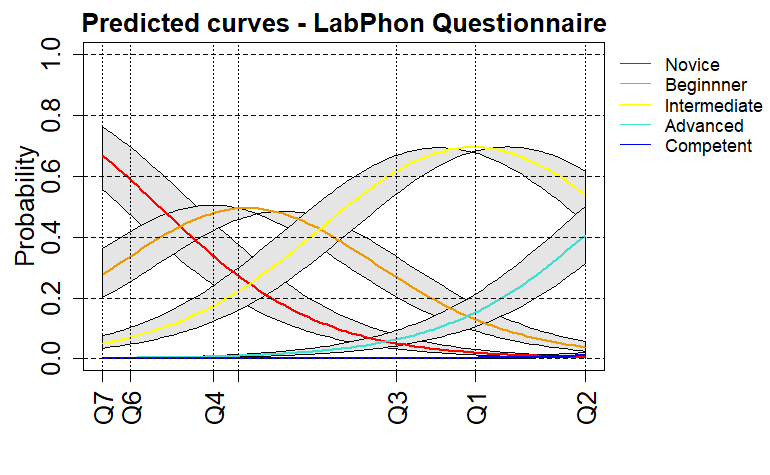

```r
abline(h=1, lty="dashed")
legend(par('usr')[2], par('usr')[4], bty='n', xpd=NA,lty=1, col=c("red", "orange2", "yellow", "turquoise", "blue", lwd=2.0),
       legend=c("Novice", "Beginnner", "Intermediate", "Advanced", "Competent"))
```

```r
png(filename = "rating.png", width = 20, height = 15, units = "cm", res = 300)

par(oma=c(0, 0, 0, 6), mgp=c(2, 1, 0))
xlim = c(min(mdl.clmm$beta), max(mdl.clmm$beta))
ylim = c(0,1)
plot(0,0,xlim=xlim, ylim=ylim, type="n", ylab=expression(Probability), xlab="", xaxt = "n",main="Predicted curves - LabPhon Questionnaire",cex=2,cex.lab=1.5,cex.main=1.5,cex.axis=1.5)
axis(side = 1, at = c(0,mdl.clmm$beta),labels = levels(rating$Questions), las=2,cex=2,cex.lab=1.5,cex.axis=1.5)
xs = seq(xlim[1], xlim[2], length.out=100)
lines(xs, plogis(mdl.clmm$Theta[1] - xs), col='red', lwd=2.0)
lines(xs, plogis(mdl.clmm$Theta[2] - xs)-plogis(mdl.clmm$Theta[1] - xs), col='orange2', lwd=2.0)
lines(xs, plogis(mdl.clmm$Theta[3] - xs)-plogis(mdl.clmm$Theta[2] - xs), col='yellow', lwd=2.0)
lines(xs, plogis(mdl.clmm$Theta[4] - xs)-plogis(mdl.clmm$Theta[3] - xs), col='turquoise', lwd=2.0)
lines(xs, 1-(plogis(mdl.clmm$Theta[4] - xs)), col='blue', lwd=2.0)
abline(v=c(0,mdl.clmm$beta),lty=3)
abline(h=0, lty="dashed")
abline(h=0.2, lty="dashed")
abline(h=0.4, lty="dashed")
abline(h=0.6, lty="dashed")
abline(h=0.8, lty="dashed")
abline(h=1, lty="dashed")
legend(par('usr')[2], par('usr')[4], bty='n', xpd=NA,lty=1, col=c("red", "orange2", "yellow", "turquoise", "blue", lwd=2.0),
       legend=c("Novice", "Beginnner", "Intermediate", "Advanced", "Competent"))

dev.off()
```

```r
png(filename = "rating2.png", width = 20, height = 15, units = "cm", res = 300)

par(oma=c(0, 0, 0, 6), mgp=c(2, 1, 0))
xlim = c(min(mdl.clmm$beta), max(mdl.clmm$beta))
ylim = c(0,1)
plot(0,0,xlim=xlim, ylim=ylim, type="n", ylab=expression(Probability), xlab="", xaxt = "n",main="Predicted curves - LabPhon Questionnaire",cex=2,cex.lab=1.5,cex.main=1.5,cex.axis=1.5)
axis(side = 1, at = c(0,mdl.clmm$beta),labels = levels(rating$Questions), las=2,cex=2,cex.lab=1.5,cex.axis=1.5)
xs = seq(xlim[1], xlim[2], length.out=100)

#+CI
lines(xs, plogis(mdl.clmm$Theta[1]+(summary(mdl.clmm)$coefficient[,2][[1]]/1.96) - xs), col='red')
lines(xs, plogis(mdl.clmm$Theta[2]+(summary(mdl.clmm)$coefficient[,2][[2]]/1.96) - xs)-plogis(mdl.clmm$Theta[1]+(summary(mdl.clmm)$coefficient[,2][[1]]/1.96) - xs), col='orange2')
lines(xs, plogis(mdl.clmm$Theta[3]+(summary(mdl.clmm)$coefficient[,2][[3]]/1.96) - xs)-plogis(mdl.clmm$Theta[2]+(summary(mdl.clmm)$coefficient[,2][[2]]/1.96) - xs), col='yellow')
lines(xs, plogis(mdl.clmm$Theta[4]+(summary(mdl.clmm)$coefficient[,2][[4]]/1.96) - xs)-plogis(mdl.clmm$Theta[3]+(summary(mdl.clmm)$coefficient[,2][[3]]/1.96) - xs), col='turquoise')
lines(xs, 1-(plogis(mdl.clmm$Theta[4]+(summary(mdl.clmm)$coefficient[,2][[4]]/1.96) - xs)), col='blue')

#-CI
lines(xs, plogis(mdl.clmm$Theta[1]-(summary(mdl.clmm)$coefficient[,2][[1]]/1.96) - xs), col='red')
lines(xs, plogis(mdl.clmm$Theta[2]-(summary(mdl.clmm)$coefficient[,2][[2]]/1.96) - xs)-plogis(mdl.clmm$Theta[1]-(summary(mdl.clmm)$coefficient[,2][[1]]/1.96) - xs), col='orange2')
lines(xs, plogis(mdl.clmm$Theta[3]-(summary(mdl.clmm)$coefficient[,2][[3]]/1.96) - xs)-plogis(mdl.clmm$Theta[2]-(summary(mdl.clmm)$coefficient[,2][[2]]/1.96) - xs), col='yellow')
lines(xs, plogis(mdl.clmm$Theta[4]-(summary(mdl.clmm)$coefficient[,2][[4]]/1.96) - xs)-plogis(mdl.clmm$Theta[3]-(summary(mdl.clmm)$coefficient[,2][[3]]/1.96) - xs), col='turquoise')
lines(xs, 1-(plogis(mdl.clmm$Theta[4]-(summary(mdl.clmm)$coefficient[,2][[4]]/1.96) - xs)), col='blue')

# fill area around CI using c(x, rev(x)), c(y2, rev(y1))
polygon(c(xs, rev(xs)),
        c(plogis(mdl.clmm$Theta[1]+(summary(mdl.clmm)$coefficient[,2][[1]]/1.96) - xs), rev(plogis(mdl.clmm$Theta[1]-(summary(mdl.clmm)$coefficient[,2][[1]]/1.96) - xs))), col = "gray90")

polygon(c(xs, rev(xs)),
        c(plogis(mdl.clmm$Theta[2]+(summary(mdl.clmm)$coefficient[,2][[2]]/1.96) - xs)-plogis(mdl.clmm$Theta[1]+(summary(mdl.clmm)$coefficient[,2][[1]]/1.96) - xs), rev(plogis(mdl.clmm$Theta[2]-(summary(mdl.clmm)$coefficient[,2][[2]]/1.96) - xs)-plogis(mdl.clmm$Theta[1]-(summary(mdl.clmm)$coefficient[,2][[1]]/1.96) - xs))), col = "gray90")


polygon(c(xs, rev(xs)),
        c(plogis(mdl.clmm$Theta[3]+(summary(mdl.clmm)$coefficient[,2][[3]]/1.96) - xs)-plogis(mdl.clmm$Theta[2]+(summary(mdl.clmm)$coefficient[,2][[2]]/1.96) - xs), rev(plogis(mdl.clmm$Theta[3]-(summary(mdl.clmm)$coefficient[,2][[3]]/1.96) - xs)-plogis(mdl.clmm$Theta[2]-(summary(mdl.clmm)$coefficient[,2][[2]]/1.96) - xs))), col = "gray90")

polygon(c(xs, rev(xs)),
        c(plogis(mdl.clmm$Theta[4]+(summary(mdl.clmm)$coefficient[,2][[4]]/1.96) - xs)-plogis(mdl.clmm$Theta[3]+(summary(mdl.clmm)$coefficient[,2][[3]]/1.96) - xs), rev(plogis(mdl.clmm$Theta[4]-(summary(mdl.clmm)$coefficient[,2][[4]]/1.96) - xs)-plogis(mdl.clmm$Theta[3]-(summary(mdl.clmm)$coefficient[,2][[3]]/1.96) - xs))), col = "gray90")


polygon(c(xs, rev(xs)),
        c(1-(plogis(mdl.clmm$Theta[4]-(summary(mdl.clmm)$coefficient[,2][[4]]/1.96) - xs)), rev(1-(plogis(mdl.clmm$Theta[4]+(summary(mdl.clmm)$coefficient[,2][[4]]/1.96) - xs)))), col = "gray90")

lines(xs, plogis(mdl.clmm$Theta[1] - xs), col='red', lwd=2.0)
lines(xs, plogis(mdl.clmm$Theta[2] - xs)-plogis(mdl.clmm$Theta[1] - xs), col='orange2', lwd=2.0)
lines(xs, plogis(mdl.clmm$Theta[3] - xs)-plogis(mdl.clmm$Theta[2] - xs), col='yellow', lwd=2.0)
lines(xs, plogis(mdl.clmm$Theta[4] - xs)-plogis(mdl.clmm$Theta[3] - xs), col='turquoise', lwd=2.0)
lines(xs, 1-(plogis(mdl.clmm$Theta[4] - xs)), col='blue', lwd=2.0)


abline(v=c(0,mdl.clmm$beta),lty=3)
abline(h=0, lty="dashed")
abline(h=0.2, lty="dashed")
abline(h=0.4, lty="dashed")
abline(h=0.6, lty="dashed")
abline(h=0.8, lty="dashed")
abline(h=1, lty="dashed")
legend(par('usr')[2], par('usr')[4], bty='n', xpd=NA,lty=1, col=c("red", "orange2", "yellow", "turquoise", "blue", lwd=2.0),
       legend=c("Novice", "Beginnner", "Intermediate", "Advanced", "Competent"))
dev.off()
```

# 4 Word Cloud and network analysis

For word clouds, we use a technique from Natural Language Processing (NLP) to identify patterns in your responses to each of the free comments parts. After processing the data, we obtain plots of the results

## 4.1 Q03_Research Interests

### 4.1.1 Reading file

```r
text <- readLines("Questionnaire_LabPhon_free1.txt")
docs <- Corpus(VectorSource(text))
# You can use the code below to look at the uploaded file
# Not run for anonymity
## inspect(docs)
```

### 4.1.2 Transformation

```r
docs <- tm_map(docs, content_transformer(tolower))
docs <- tm_map(docs, removeNumbers)
docs <- tm_map(docs, removeWords, stopwords("english"))
docs <- tm_map(docs, removePunctuation)
docs <- tm_map(docs, stripWhitespace)
docs <- tm_map(docs, content_transformer(gsub), pattern = 'contrôle', replacement = 'control')
docs <- tm_map(docs, content_transformer(gsub), pattern = 'français', replacement = 'French')
docs <- tm_map(docs, content_transformer(gsub), pattern = 'mémoire', replacement = 'dissertation')
docs <- tm_map(docs, content_transformer(gsub), pattern = 'exécutif', replacement = 'executif')
docs <- tm_map(docs, content_transformer(gsub), pattern = 'lhypothèse', replacement = 'hypothesis')
docs <- tm_map(docs, content_transformer(gsub), pattern = 'étude', replacement = 'study')
docs <- tm_map(docs, content_transformer(gsub), pattern = 'avancée', replacement = 'advanced')
docs <- tm_map(docs, content_transformer(gsub), pattern = 'très', replacement = 'very')
```

```r
dtm <- TermDocumentMatrix(docs)
m <- as.matrix(dtm)
v <- sort(rowSums(m),decreasing=TRUE)
d <- data.frame(word = names(v),freq=v)
head(d, 10)
```

|  | word | freq |
| --- | --- | --- |
| interested | interested | 13 |
| speech | speech | 7 |
| perception | perception | 6 |
| french | french | 6 |
| phonetics | phonetics | 6 |
| acoustic | acoustic | 6 |
| language | language | 5 |
| analysis | analysis | 5 |
| phonology | phonology | 5 |
| production | production | 5 |

### 4.1.3 WordCloud

[output not shown]

[output cut: 217 more lines]

[output not shown]

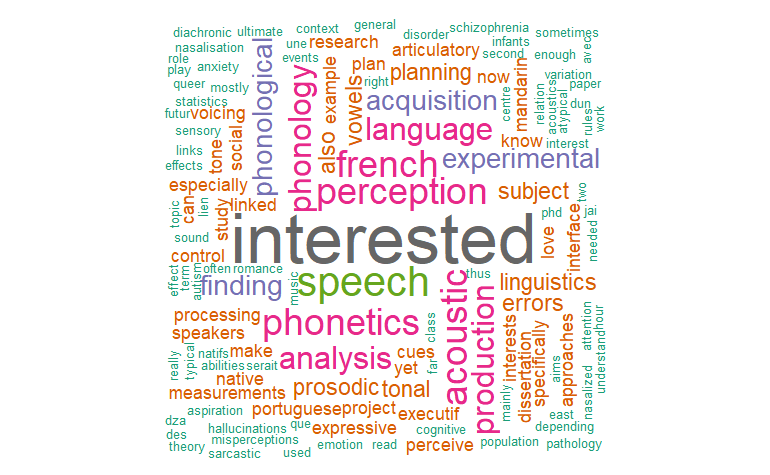

```r
set.seed(1234)
wordcloud(words = d$word, freq = d$freq, min.freq = 1,
          max.words=300, random.order=FALSE, rot.per=0.35,
          colors=brewer.pal(8, "Dark2"))
```

```r
png(filename = "Cloud1.png", width = 20, height = 15, units = "cm", res = 300)

set.seed(1234)
wordcloud(words = d$word, freq = d$freq, min.freq = 1,
          max.words=300, random.order=FALSE, rot.per=0.35,
          colors=brewer.pal(8, "Dark2"))
dev.off()
```

### 4.1.4 Network analysis

```r
toks <- tokens(text)

toks
```

```
Tokens consisting of 14 documents.
text1 :
 [1] "\""         "I"          "am"         "mostly"     "interested"
 [6] "in"         "perception" "but"        "the"        "two"
[11] "are"        "often"
[ ... and 70 more ]

text2 :
 [1] "cross-linguistic"  "sound"             "variation"
 [4] "in"                "speech"            "perception"
 [7] "and"               "production"        "Phonological"
[10] "context"           "and"               "social-contextual"
[ ... and 10 more ]

text3 :
 [1] "\""           "I"            "would"        "love"
 [5] "to"           "make"         "a"            "project"
 [9] "about"        "phonological" "cues"         "depending"
[ ... and 48 more ]

text4 :
 [1] "\""           ";"            "I"            "am"
 [5] "interested"   "mainly"       "in"           "prosodic"
 [9] "analysis"     ","            "articulatory" "phonetics"
[ ... and 57 more ]

text5 :
[1] "prosody"         "and"             "intonationtonal"
[4] "language"        "acquisition"     "experimental"
[7] "linguistics"     "phono-syntaxe"

text6 :
 [1] "\""             "Sociophonetics" ","              "phonology"
 [5] ","              "Queer"          "Theory"         ","
 [9] "gender"         ","              "sexuality"      ","
[ ... and 22 more ]

[ reached max_ndoc ... 8 more documents ]
```

```r
toks2 <- toks %>%
  tokens(remove_punct = TRUE, remove_symbols = TRUE,
         remove_numbers = TRUE) %>%
  tokens_remove(stopwords("en"), padding = FALSE) %>%
  tokens_tolower()

toks2
```

```
Tokens consisting of 14 documents.
text1 :
 [1] "mostly"      "interested"  "perception"  "two"
 [5] "often"       "linked"      "thus"        "needed"
 [9] "understand"  "language"    "acquisition" "processing"
[ ... and 28 more ]

text2 :
 [1] "cross-linguistic"  "sound"             "variation"
 [4] "speech"            "perception"        "production"
 [7] "phonological"      "context"           "social-contextual"
[10] "effects"           "l2"                "perception"
[ ... and 5 more ]

text3 :
 [1] "love"         "make"         "project"      "phonological"
 [5] "cues"         "depending"    "social"       "class"
 [9] "french"       "know"         "enough"       "right"
[ ... and 14 more ]

text4 :
 [1] "interested"   "mainly"       "prosodic"     "analysis"
 [5] "articulatory" "phonetics"    "speech-music" "interface"
 [9] "expressive"   "speech"       "besides"      "also"
[ ... and 21 more ]

text5 :
[1] "prosody"         "intonationtonal" "language"
[4] "acquisition"     "experimental"    "linguistics"
[7] "phono-syntaxe"

text6 :
 [1] "sociophonetics" "phonology"      "queer"          "theory"
 [5] "gender"         "sexuality"      "romance"        "languages"
 [9] "french"         "portuguese"     "metropolitan"   "french"
[ ... and 8 more ]

[ reached max_ndoc ... 8 more documents ]
```

```r
fcmat_toks2 <- toks2 %>%
  fcm(context = "window", count = "weighted")
fcmat_toks2
```

```
Feature co-occurrence matrix of: 282 by 282 features.
            features
features     mostly interested perception       two     often   linked
  mostly          0          1        0.5 0.3333333 0.2500000 0.200000
  interested      0          0        1.5 0.5000000 0.3333333 0.250000
  perception      0          0        0.5 1.0000000 0.5000000 1.533333
  two             0          0        0   0         1.0000000 0.500000
  often           0          0        0   0         0         1.000000
  linked          0          0        0   0         0         0
  thus            0          0        0   0         0         0
  needed          0          0        0   0         0         0
  understand      0          0        0   0         0         0
  language        0          0        0   0         0         0
            features
features          thus    needed understand  language
  mostly     0         0          0         0
  interested 0.2000000 0          0         0.5000000
  perception 0.2500000 0.2000000  0         0
  two        0.3333333 0.2500000  0.2000000 0
  often      0.5000000 0.3333333  0.2500000 0.2000000
  linked     1.0000000 0.5000000  0.3333333 0.2500000
  thus       0         1.0000000  0.5000000 0.3333333
  needed     0         0          1.0000000 0.5000000
  understand 0         0          0         1.0000000
  language   0         0          0         0
[ reached max_feat ... 272 more features, reached max_nfeat ... 272 more features ]
```

```r
feat <- names(topfeatures(fcmat_toks2, 40, scheme = "count"))

feat
```

```
 [1] "production"   "acoustic"     "speech"       "subject"
 [5] "errors"       "finding"      "prosodic"     "also"
 [9] "vowels"       "acquisition"  "approaches"   "speakers"
[13] "phonetics"    "expressive"   "tone"         "perceive"
[17] "tonal"        "especially"   "can"          "analysis"
[21] "experimental" "en"           "course"       "mandarin"
[25] "measurements" "side"         "intonation"   "related"
[29] "processing"   "portuguese"   "producing"    "besides"
[33] "figure"       "natural"      "consequently" "français"
[37] "now"          "really"       "subjects"     "native"
```

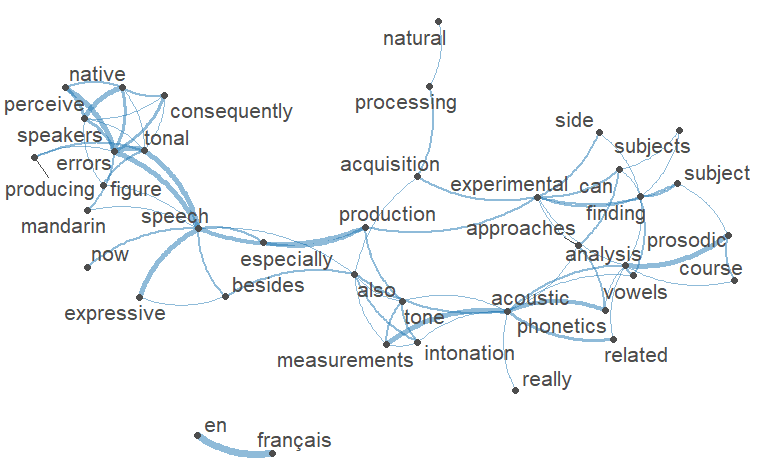

```r
fcmat_toks_subset <- fcmat_toks2 %>%
fcm_select(feat)
textplot_network(fcmat_toks_subset)
```

```r
NA
NA
```

```r
png(filename = "Network1.png", width = 20, height = 15, units = "cm", res = 300)

textplot_network(fcmat_toks_subset)
dev.off()
```

## 4.2 Q04_Programme/level

### 4.2.1 Reading file

```r
text <- readLines("Questionnaire_LabPhon_free2.txt")
docs <- Corpus(VectorSource(text))
# You can use the code below to look at the uploaded file
# Not run for anonymity
## inspect(docs)
```

### 4.2.2 Transformation

```r
docs <- tm_map(docs, content_transformer(tolower))
docs <- tm_map(docs, removeNumbers)
docs <- tm_map(docs, removeWords, stopwords("english"))
docs <- tm_map(docs, removePunctuation)
docs <- tm_map(docs, stripWhitespace)
docs <- tm_map(docs, content_transformer(gsub), pattern = 'université', replacement = 'university')
docs <- tm_map(docs, content_transformer(gsub), pattern = 'phonétique', replacement = 'phonetics')
docs <- tm_map(docs, content_transformer(gsub), pattern = 'phonologie', replacement = 'phonology')
```

```r
dtm <- TermDocumentMatrix(docs)
m <- as.matrix(dtm)
v <- sort(rowSums(m),decreasing=TRUE)
d <- data.frame(word = names(v),freq=v)
head(d, 10)
```

|  | word | freq |
| --- | --- | --- |
| paris | paris | 12 |
| phonology | phonology | 12 |
| phonetics | phonetics | 8 |
| linguistics | linguistics | 6 |
| year | year | 6 |
| university | university | 5 |
| english | english | 4 |
| first | first | 4 |
| language | language | 4 |
| speech | speech | 4 |

### 4.2.3 WordCloud

[output not shown]

[output cut: 35 more lines]

[output not shown]

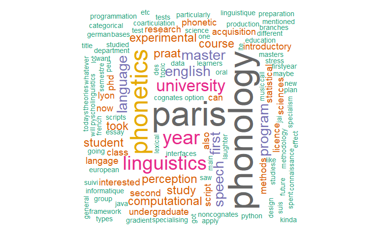

```r
set.seed(1234)
wordcloud(words = d$word, freq = d$freq, min.freq = 1,
          max.words=300, random.order=FALSE, rot.per=0.35,
          colors=brewer.pal(8, "Dark2"))
```

```r
png(filename = "Cloud2.png", width = 20, height = 15, units = "cm", res = 300)

set.seed(1234)
wordcloud(words = d$word, freq = d$freq, min.freq = 1,
          max.words=300, random.order=FALSE, rot.per=0.35,
          colors=brewer.pal(8, "Dark2"))
dev.off()
```

### 4.2.4 Network analysis

```r
toks <- tokens(text)

toks
```

```
Tokens consisting of 14 documents.
text1 :
 [1] "\""          "I"           "am"          "in"
 [5] "my"          "M1"          "of"          "English"
 [9] "Linguistics" ","           "a"           "specialism"
[ ... and 104 more ]

text2 :
 [1] "\""           "2nd"          "year"         "of"
 [5] "the"          "Master's"     "at"           "Université"
 [9] "de"           "Paris"        ","            "specialising"
[ ... and 5 more ]

text3 :
[1] "M1"           "Linguistique" "Informatique"

text4 :
 [1] "\""         "I"          "am"         "now"        "a"
 [6] "first-year" "in"         "LTE"        "at"         "Paris"
[11] "7"          "."
[ ... and 29 more ]

text5 :
 [1] "\""            "Bases"         "de"            "programmation"
 [5] "de"            "python"        "et"            "de"
 [9] "Praat"         "script"        ","             "un"
[ ... and 7 more ]

text6 :
 [1] "M1"         "Phonetics"  "and"        "Phonology"  "at"
 [6] "the"        "Université" "de"         "Paris"      "or"
[11] "whatever"   "they"
[ ... and 6 more ]

[ reached max_ndoc ... 8 more documents ]
```

```r
toks2 <- toks %>%
  tokens(remove_punct = TRUE, remove_symbols = TRUE,
         remove_numbers = TRUE) %>%
  tokens_remove(stopwords("en"), padding = FALSE) %>%
  tokens_tolower()

toks2
```

```
Tokens consisting of 14 documents.
text1 :
 [1] "m1"          "english"     "linguistics" "specialism"
 [5] "english"     "studies"     "essay"       "topic"
 [9] "european"    "french"      "learners"    "perception"
[ ... and 42 more ]

text2 :
[1] "2nd"          "year"         "master's"     "université"
[5] "de"           "paris"        "specialising" "phonetics"
[9] "phonology"

text3 :
[1] "m1"           "linguistique" "informatique"

text4 :
 [1] "now"           "first-year"    "lte"           "paris"
 [5] "undergraduate" "study"         "science"       "education"
 [9] "lyon2"         "m2"            "plan"          "apply"
[ ... and 4 more ]

text5 :
 [1] "bases"         "de"            "programmation" "de"
 [5] "python"        "et"            "de"            "praat"
 [9] "script"        "un"            "peu"           "de"
[ ... and 4 more ]

text6 :
 [1] "m1"         "phonetics"  "phonology"  "université" "de"
 [6] "paris"      "whatever"   "going"      "call"       "now"

[ reached max_ndoc ... 8 more documents ]
```

```r
fcmat_toks2 <- toks2 %>%
  fcm(context = "window", count = "weighted")
fcmat_toks2
```

```
Feature co-occurrence matrix of: 184 by 184 features.
             features
features      m1   english linguistics specialism   studies     essay
  m1           0 1.2500000         0.5  0.3333333 0.2000000 0
  english      0 0.6666667         1.5  1.5000000 1.2500000 0.7000000
  linguistics  0 0                 0    1.0000000 0.3333333 0.2500000
  specialism   0 0                 0    0         0.5000000 0.3333333
  studies      0 0                 0    0         0         1.0000000
  essay        0 0                 0    0         0         0
  topic        0 0                 0    0         0         0
  european     0 0                 0    0         0         0
  french       0 0                 0    0         0         0
  learners     0 0                 0    0         0         0
             features
features          topic  european    french  learners
  m1          0         0         0         0
  english     0.3333333 0.4500000 0.4500000 0.3333333
  linguistics 0.2000000 0         0         0
  specialism  0.2500000 0.2000000 0         0
  studies     0.5000000 0.3333333 0.2500000 0.2000000
  essay       1.0000000 0.5000000 0.3333333 0.2500000
  topic       0         1.0000000 0.5000000 0.3333333
  european    0         0         1.0000000 0.5000000
  french      0         0         0         1.0000000
  learners    0         0         0         0
[ reached max_feat ... 174 more features, reached max_nfeat ... 174 more features ]
```

```r
feat <- names(topfeatures(fcmat_toks2, 40, scheme = "count"))

feat
```

```
 [1] "phonology"     "master"        "de"            "computational"
 [5] "paris"         "phonetics"     "et"            "student"
 [9] "university"    "phonologie"    "phonetic"      "langage"
[13] "course"        "phonétique"    "introductory"  "year"
[17] "program"       "speech"        "methods"       "language"
[21] "analysis"      "du"            "also"          "undergraduate"
[25] "got"           "l3"            "follow"        "à"
[29] "lot"           "acoustic"      "lyon"          "theoretical"
[33] "experimental"  "apply"         "dublin"        "l'université"
[37] "tests"         "peu"           "degree"        "perception"
```

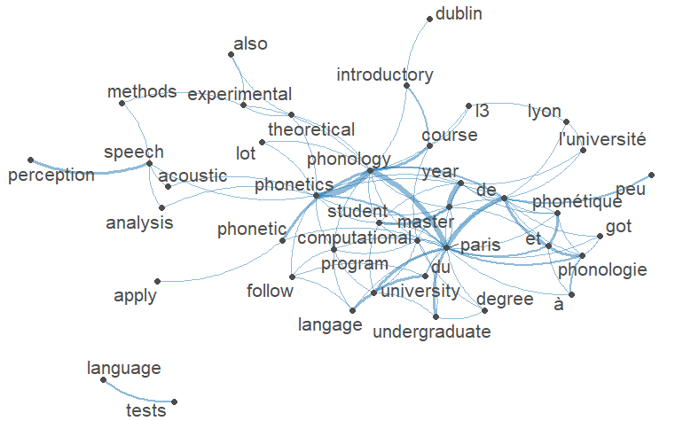

```r
fcmat_toks_subset <- fcmat_toks2 %>%
fcm_select(feat)
textplot_network(fcmat_toks_subset)
```

```r
NA
NA
```

```r
png(filename = "Network2.png", width = 20, height = 15, units = "cm", res = 300)

textplot_network(fcmat_toks_subset)
dev.off()
```

## 4.3 Q07_Other software/platform

### 4.3.1 Reading file

```r
text <- readLines("Questionnaire_LabPhon_free3.txt")
docs <- Corpus(VectorSource(text))
# You can use the code below to look at the uploaded file
# Not run for anonymity
## inspect(docs)
```

### 4.3.2 Transformation

```r
docs <- tm_map(docs, content_transformer(tolower))
docs <- tm_map(docs, removeNumbers)
docs <- tm_map(docs, removeWords, stopwords("english"))
docs <- tm_map(docs, removePunctuation)
docs <- tm_map(docs, stripWhitespace)
docs <- tm_map(docs, content_transformer(gsub), pattern = 'lycée', replacement = 'college')
docs <- tm_map(docs, content_transformer(gsub), pattern = 'utilisé', replacement = 'used')
docs <- tm_map(docs, content_transformer(gsub), pattern = 'experiments', replacement = 'experiment')
docs <- tm_map(docs, removeWords, c("used", "use", "using"))
```

```r
dtm <- TermDocumentMatrix(docs)
m <- as.matrix(dtm)
v <- sort(rowSums(m),decreasing=TRUE)
d <- data.frame(word = names(v), freq=v)
head(d, 10)
```

|  | word | freq |
| --- | --- | --- |
| praat | praat | 21 |
| analyses | analyses | 15 |
| experiment | experiment | 9 |
| statistical | statistical | 9 |
| acoustic | acoustic | 8 |
| perception | perception | 7 |
| python | python | 5 |
| winpitch | winpitch | 4 |
| data | data | 4 |
| pitch | pitch | 3 |

### 4.3.3 WordCloud

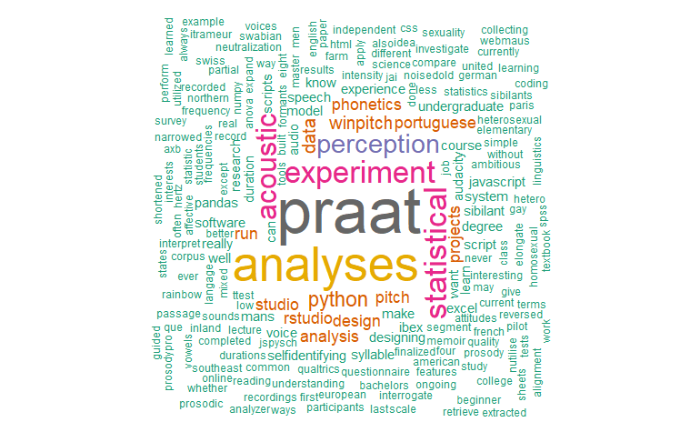

```r
set.seed(1234)
wordcloud(words = d$word, freq = d$freq, min.freq = 1,
          max.words=300, random.order=FALSE, rot.per=0.35,
          colors=brewer.pal(8, "Dark2"))
```

```r
png(filename = "Cloud3.png", width = 20, height = 15, units = "cm", res = 300)

set.seed(1234)
wordcloud(words = d$word, freq = d$freq, min.freq = 1,
          max.words=300, random.order=FALSE, rot.per=0.35,
          colors=brewer.pal(8, "Dark2"))
dev.off()
```

### 4.3.4 Network analysis

```r
toks <- tokens(text)

toks
```

```
Tokens consisting of 15 documents.
text1 :
 [1] "\""       "I"        "have"     "used"     "Praat"    "and"
 [7] "Audacity" "to"       "record"   "and"      "segment"  "audio"
[ ... and 49 more ]

text2 :
 [1] "Acoustic"    "analyses"    ":"           "Praat"
 [5] "and"         "WinPitch"    "."           "Statistical"
 [9] "analyses"    ":"           "Rstudio"     "."
[ ... and 5 more ]

text3 :
 [1] "\""        "I"         "finalized" "a"         "Science"
 [6] "du"        "Langage"   "Master"    "with"      "a"
[11] "memoir"    ","
[ ... and 59 more ]

text4 :
 [1] "I"           "use"         "Praat"       "for"
 [5] "acoustic"    "analyses"    "."           "As"
 [9] "for"         "statistical" "analyses"    "I"
[ ... and 19 more ]

text5 :
 [1] "\""          "I"           "can"         "use"
 [5] "python"      "for"         "the"         "simple"
 [9] "statistical" "analyses"    ","           "and"
[ ... and 52 more ]

text6 :
 [1] "\""       "The"      "only"     "software" "I"        "have"
 [7] "ever"     "used"     "is"       "Praat"    "."        "I"
[ ... and 204 more ]

[ reached max_ndoc ... 9 more documents ]
```

```r
toks2 <- toks %>%
  tokens(remove_punct = TRUE, remove_symbols = TRUE,
         remove_numbers = TRUE) %>%
  tokens_remove(stopwords("en"), padding = FALSE) %>%
  tokens_tolower()

toks2
```

```
Tokens consisting of 15 documents.
text1 :
 [1] "used"     "praat"    "audacity" "record"   "segment"  "audio"
 [7] "praat"    "run"      "acoustic" "analyses" "duration" "formants"
[ ... and 19 more ]

text2 :
 [1] "acoustic"    "analyses"    "praat"       "winpitch"
 [5] "statistical" "analyses"    "rstudio"     "designing"
 [9] "perception"  "experiment"  "jspysch"

text3 :
 [1] "finalized"  "science"    "du"         "langage"    "master"
 [6] "memoir"     "experiment" "perception" "noised"     "speech"
[11] "sounds"     "without"
[ ... and 17 more ]

text4 :
 [1] "use"         "praat"       "acoustic"    "analyses"
 [5] "statistical" "analyses"    "use"         "python"
 [9] "pandas"      "numpy"       "experience"  "design"
[ ... and 2 more ]

text5 :
 [1] "can"         "use"         "python"      "simple"
 [5] "statistical" "analyses"    "script"      "can"
 [9] "make"        "statistical" "analyses"    "r"
[ ... and 21 more ]

text6 :
 [1] "software"      "ever"          "used"          "praat"
 [5] "used"          "undergraduate" "united"        "states"
 [9] "bachelor's"    "degree"        "linguistics"   "elementary"
[ ... and 100 more ]

[ reached max_ndoc ... 9 more documents ]
```

```r
fcmat_toks2 <- toks2 %>%
  fcm(context = "window", count = "weighted")
fcmat_toks2
```

```
Feature co-occurrence matrix of: 228 by 228 features.
          features
features   used    praat audacity    record   segment     audio
  used      1.9 7.533333     0.50 0.3333333 0.2500000 0.2000000
  praat     0   0.400000     1.25 0.8333333 0.8333333 1.2500000
  audacity  0   0            0    1.0000000 0.5000000 0.3333333
  record    0   0            0    0         1.0000000 0.5000000
  segment   0   0            0    0         0         1.0000000
  audio     0   0            0    0         0         0
  run       0   0            0    0         0         0
  acoustic  0   0            0    0         0         0
  analyses  0   0            0    0         0         0
  duration  0   0            0    0         0         0
          features
features         run  acoustic analyses  duration
  used     0         1.1666667 0        0.2000000
  praat    1.3333333 4.5833333 6.483333 0.2500000
  audacity 0.2000000 0         0        0
  record   0.2500000 0.2000000 0        0
  segment  0.3333333 0.2500000 0.200000 0
  audio    0.5000000 0.3333333 0.250000 0.2000000
  run      0         1.0000000 1.000000 0.3333333
  acoustic 0         0         6.866667 0.5000000
  analyses 0         0         3.300000 1.0000000
  duration 0         0         0        0
[ reached max_feat ... 218 more features, reached max_nfeat ... 218 more features ]
```

```r
feat <- names(topfeatures(fcmat_toks2, 40, scheme = "count"))

feat
```

```
 [1] "statistical"   "analyses"      "use"           "winpitch"
 [5] "experiments"   "data"          "praat"         "perception"
 [9] "voice"         "python"        "r"             "acoustic"
[13] "ibex"          "scripts"       "studio"        "rstudio"
[17] "pandas"        "analysis"      "design"        "make"
[21] "know"          "really"        "degree"        "experiment"
[25] "phonetics"     "excel"         "man's"         "syllable"
[29] "pitch"         "undergraduate" "projects"      "using"
[33] "first"         "script"        "tests"         "extracted"
[37] "heterosexual"  "beginner"      "farm"          "system"
```

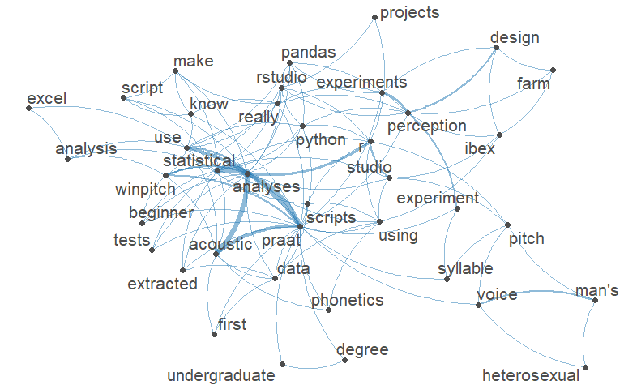

```r
fcmat_toks_subset <- fcmat_toks2 %>%
fcm_select(feat)
textplot_network(fcmat_toks_subset)
```

```r
NA
NA
```

```r
png(filename = "Network3.png", width = 20, height = 15, units = "cm", res = 300)

textplot_network(fcmat_toks_subset)
dev.off()
```